# 29 Automatic Differentiation for Asset Liability Management

Author

Alec Loudenback

## 29.1 Chapter Overview

Asset liability modeling requires computing derivatives of portfolio values with respect to yield curve changes. Traditional approaches use finite difference methods or analytical approximations, but automatic differentiation (“autodiff” or “AD”) provides exact derivatives with minimal additional computation. This chapter demonstrates how to implement ALM workflows using autodiff in Julia.

```julia
using FinanceCore: Cashflow    # provides Cashflow object
using DifferentiationInterface # autodiff
using DifferentiationInterface: AutoForwardDiff, gradient, hessian
using DifferentiationInterface: value_gradient_and_hessian
import ForwardDiff             # specific autodiff technique
using CairoMakie               # plotting
using DataInterpolations       # yield curve interpolation
using Transducers              # data aggregation
using JuMP, HiGHS              # portfolio optimization
using LinearAlgebra            # math
using BenchmarkTools           # benchmarking
using OhMyThreads              # multi-threading
```

## 29.2 Interest Rate Curve Setup

We start by constructing a yield curve using cubic spline interpolation:

The `curve` function creates a discount factor curve from zero rates and time points. This curve will serve as input to our `value` function, which makes it straightforward to compute sensitivities by differentiating with respect to the rate parameters.

```julia
zero_rates = [0.01, 0.02, 0.02, 0.03, 0.05, 0.055] # continuous, annualised
times = [1.0, 2.0, 3.0, 5.0, 10.0, 20.0]

function curve(zero_rates, times)
    discounts = [1.0; exp.(-zero_rates .* times)]
    DataInterpolations.CubicSpline(discounts, [0.; times])
end

c = curve(zero_rates, times)
```

```
CubicSpline with 7 points
┌──────┬──────────┐
│    t │        u │
├──────┼──────────┤
│  0.0 │      1.0 │
│  1.0 │  0.99005 │
│  2.0 │ 0.960789 │
│  3.0 │ 0.941765 │
│  5.0 │ 0.860708 │
│ 10.0 │ 0.606531 │
│ 20.0 │ 0.332871 │
└──────┴──────────┘
```

## 29.3 Asset Valuation Framework

The core valuation function operates on any instrument that produces cashflows:

```julia
function value(curve, asset)
    cfs = asset(curve)
    mapreduce(cf -> cf.amount * curve(cf.time), +, cfs)
end
```

```
value (generic function with 1 method)
```

This design separates the valuation logic from the instrument definition. Each asset type implements a callable interface that generates cashflows given a yield curve. Note how the asset itself gets passed the curve (the `asset(curve)` statement) to determine the cashflows.

For fixed bonds, we create a structure that generates periodic coupon payments:

```julia
struct FixedBond{T<:Real}
    coupon::T
    tenor::Int
    periodicity::Int
end

function (b::FixedBond)(curve)
    map(1//b.periodicity:1//b.periodicity:b.tenor) do t
        Cashflow(b.coupon / b.periodicity + (t == b.tenor ? 1. : 0.), t)
    end
end

function par_yield(discount_curve, tenor, periodicity)
    dfs = discount_curve.(1//periodicity:1//periodicity:tenor)

    (1 - last(dfs)) / sum(dfs) * periodicity
end
```

The `(b::FixedBond)(curve)` function (a **callable struct**, since we are using the `b` object itself as the function invocation) takes the curve and returns an array of `Cashflow`s.

**Note**

`Cashflow` objects are part of the [JuliaActuary suite](https://juliaactuary.org/packages). This allows the cashflows to be tied with the exact timepoint that they occur, rather than needing a bunch of logic to pre-determine a timestep (annual, quarterly, etc.) for which cashflows would get bucketed. This is more efficient in many cases and much simpler code.

The `par_yield` function computes the coupon rate that prices the bond at par, which we’ll use to construct our asset universe.

```julia
FixedBond(0.08, 10, 2)(c)
```

```
20-element Vector{Cashflow{Float64, Rational{Int64}}}:
 Cashflow{Float64, Rational{Int64}}(0.04, 1//2)
 Cashflow{Float64, Rational{Int64}}(0.04, 1//1)
 Cashflow{Float64, Rational{Int64}}(0.04, 3//2)
 Cashflow{Float64, Rational{Int64}}(0.04, 2//1)
 Cashflow{Float64, Rational{Int64}}(0.04, 5//2)
 Cashflow{Float64, Rational{Int64}}(0.04, 3//1)
 Cashflow{Float64, Rational{Int64}}(0.04, 7//2)
 Cashflow{Float64, Rational{Int64}}(0.04, 4//1)
 Cashflow{Float64, Rational{Int64}}(0.04, 9//2)
 Cashflow{Float64, Rational{Int64}}(0.04, 5//1)
 Cashflow{Float64, Rational{Int64}}(0.04, 11//2)
 Cashflow{Float64, Rational{Int64}}(0.04, 6//1)
 Cashflow{Float64, Rational{Int64}}(0.04, 13//2)
 Cashflow{Float64, Rational{Int64}}(0.04, 7//1)
 Cashflow{Float64, Rational{Int64}}(0.04, 15//2)
 Cashflow{Float64, Rational{Int64}}(0.04, 8//1)
 Cashflow{Float64, Rational{Int64}}(0.04, 17//2)
 Cashflow{Float64, Rational{Int64}}(0.04, 9//1)
 Cashflow{Float64, Rational{Int64}}(0.04, 19//2)
 Cashflow{Float64, Rational{Int64}}(1.04, 10//1)
```

```julia
value(c, FixedBond(0.09, 10, 2))
```

```
1.3526976075662451
```

## 29.4 Liability Modeling

Deferred annuities require more complex modeling than fixed bonds due to policyholder behavior (optionality). The surrender rate depends on the difference between market rates and the guaranteed rate. The surrender function chosen below is arbitrary, but follows a typical pattern with much higher surrenders if the market rate on competing instruments is higher than what’s currently available. The account value accumulates at the guaranteed rate, and surrenders create negative cashflows representing benefit payments. Lastly, the `annuities` function is a wrapper function we will use to compute the portfolio value and ALM metrics later.

```julia
begin
    struct DeferredAnnuity{A,B}
        tenor::A
        rate::B
    end

    function (d::DeferredAnnuity)(curve)
        av = 1.
        map(1//12:1//12:d.tenor) do t

            # apply interest credit
            av *= exp(d.rate / 12)

            # determine market comparable rate and surrender rate
            mkt_rate = -log(curve(d.tenor) / curve(t)) / (d.tenor - t)
            rate_diff = mkt_rate - d.rate
            sr = t == d.tenor ? 1.0 : surrender_rate(rate_diff) / 12
            av_surr = av * sr
            av -= av_surr
            Cashflow(-av_surr, t)

        end
    end

    function surrender_rate(rate_diff)
        1 / (1 + exp(3 - rate_diff * 60))
    end
    function annuities(rates, portfolio)
        times = [1.0, 2.0, 3.0, 5.0, 10.0, 20.0]
        c = curve(rates, times)
        OhMyThreads.tmapreduce(
            +,
            1:length(portfolio);
            ntasks=Threads.nthreads(),
        ) do i
            value(c, portfolio[i])
        end
    end

end
```

```
annuities (generic function with 1 method)
```

Here’s what the surrender rate behavior looks like for different levels of market rates compared to a 3% crediting rate.

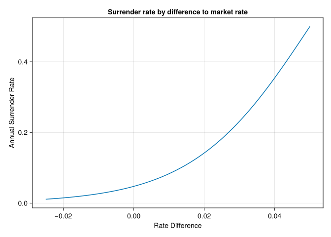

```julia
let
    cred_rate = 0.03
    mkt_rates = 0.005:0.001:0.08
    rate_diff = mkt_rates .- cred_rate

    lines(rate_diff, surrender_rate.(rate_diff),
        axis=(
            title="Surrender rate by difference to market rate",
            xlabel="Rate Difference",
            ylabel="Annual Surrender Rate"
        ))
end
```

**Note**

In production ALM runs, one may typically evaluate hundreds of thousands of in-force contracts. The threaded `annuities` aggregator mirrors that setup: it delivers the same projected liability present value while keeping the code path fully differentiable.

We model a large portfolio of these annuities with random tenors:

```julia
liabilities = map(1:100_000) do i
    tenor = rand(1:20)
    DeferredAnnuity(tenor, par_yield(c, tenor, 12))
end
```

```
100000-element Vector{DeferredAnnuity{Int64, Float64}}:
 DeferredAnnuity{Int64, Float64}(16, 0.051607152912174645)
 DeferredAnnuity{Int64, Float64}(7, 0.03847750979086058)
 DeferredAnnuity{Int64, Float64}(9, 0.04476297466971608)
 DeferredAnnuity{Int64, Float64}(12, 0.049761345150540474)
 DeferredAnnuity{Int64, Float64}(16, 0.051607152912174645)
 DeferredAnnuity{Int64, Float64}(14, 0.05108046813021651)
 DeferredAnnuity{Int64, Float64}(3, 0.019937936965500825)
 DeferredAnnuity{Int64, Float64}(10, 0.04698961087662551)
 DeferredAnnuity{Int64, Float64}(15, 0.05141229637424002)
 DeferredAnnuity{Int64, Float64}(12, 0.049761345150540474)
 ⋮
 DeferredAnnuity{Int64, Float64}(2, 0.0198981133775843)
 DeferredAnnuity{Int64, Float64}(1, 0.009988829495716861)
 DeferredAnnuity{Int64, Float64}(13, 0.05055368479631081)
 DeferredAnnuity{Int64, Float64}(5, 0.029452531739357923)
 DeferredAnnuity{Int64, Float64}(9, 0.04476297466971608)
 DeferredAnnuity{Int64, Float64}(9, 0.04476297466971608)
 DeferredAnnuity{Int64, Float64}(3, 0.019937936965500825)
 DeferredAnnuity{Int64, Float64}(2, 0.0198981133775843)
 DeferredAnnuity{Int64, Float64}(20, 0.051933558828553925)
```

**NoteConsolidating Cashflows**

Later on we will generate vectors of vectors of cashflows without any guarantee that the timepoints will line up, making aggregating cashflows by timepoint a non-obvious task. There are many ways to accomplish this, but [I like Transducers](https://juliaactuary.github.io/FinanceModels.jl/dev/faq/#Why-does-the-package-rely-on-using-Transducers?).

Transducers are unfamiliar to many people, and don’t let their presence deter you from the main points of this chapter. The details aren’t central to the point of this chapter so just skip over if confusing.

```julia
function consolidate(cashflows)

    cashflows |> # take the collection
    MapCat(identity) |> # flatten it out without changing elements
    # group by the time, and just keep and sum the amounts
    GroupBy(x -> x.time, Map(last) ⨟ Map(x -> x.amount), +) |>
    # perform the aggregation and keep the final grouped result
    foldxl(Transducers.right)
end
```

```
consolidate (generic function with 1 method)
```

Example:

```julia
cashflow_vectors = [l(c) for l in liabilities];
```

And running `consolidate` groups the cashflows into `timepoint => amount` pairs.

```julia
consolidate(cashflow_vectors);
```

Here’s a visualization of the liability cashflows, showing that when the interest rates are bumped up slightly, there are more surrenders that occur earlier on (so there are fewer policies around at the time of each maturity). Negative cashflows are outflows:

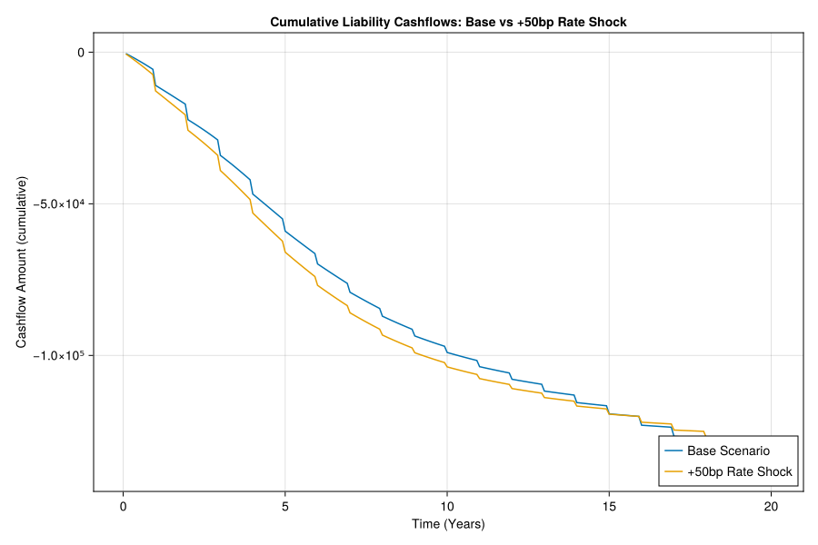

```julia
let
    d = consolidate([p(c) for p in liabilities])
    ks = collect(keys(d)) |> sort!
    vs = [d[k] for k in ks]

    c2 = curve(zero_rates .+ 0.005, times)
    d2 = consolidate([p(c2) for p in liabilities])
    ks2 = collect(keys(d2)) |> sort!
    vs2 = [d2[k] for k in ks2]

    f = Figure(size = (900, 600))
    ax = Axis(f[1, 1],
        xlabel = "Time (Years)",
        ylabel = "Cashflow Amount (cumulative)",
        title = "Cumulative Liability Cashflows: Base vs +50bp Rate Shock",
    )

    lines!(ax, ks, cumsum(vs), label = "Base Scenario")

    lines!(ax, ks2, cumsum(vs2), label = "+50bp Rate Shock")

    axislegend(ax, position = :rb)

    f
end
```

With an upward-sloping yield curve, without a surrender charge or market value adjustment, many mid-to-late-duration policyholders elect to surrender instead of holding to maturity.

## 29.5 Computing Derivatives with Autodiff

Rather than approximating derivatives through finite differences, autodiff computes exact values, gradients, and Hessians. The concepts and background are covered in Chapter 16.

The `value_gradient_and_hessian` function returns the present value, key rate durations (gradient), and convexities (Hessian diagonal) for the entire liability portfolio. We compute similar derivatives for each potential asset.

```julia
vgh_liab = let
    f = z -> annuities(z, liabilities)
    value_gradient_and_hessian(f, AutoForwardDiff(), zero_rates)
end
```

```
(-102332.78946191077, [11543.482372643468, 29949.20997121709, 29548.232180032872, 255803.8160932153, 123773.49893058585, 6585.144884770879], [-167396.1584407914 198138.75520266095 … 9147.31198520935 -42004.84014586981; 198138.75520266074 -1.6783528330866047e6 … 2.480890351508268e6 1.2673974433484909…
```

### 29.5.1 Gradients and Hessians in ALM

Let’s dive into the results here a little bit.

The first element of `vgh_liab` is the value of the liability portfolio using the yield curve constructed earlier:

```julia
vgh_liab[1]
```

```
-102332.78946191077
```

The second element of `vgh_liab` is the partial derivative with respect to each of the inputs (here, just the `zero_rates` that dictate the curve). The sum of the partials is the (dollar) sensitivity of the liabilities to a parallel shift in rates—a dollar duration, which becomes the effective duration once divided by the value (shown below).

```julia
@show sum(vgh_liab[2])
vgh_liab[2]
```

```
sum(vgh_liab[2]) = 457203.3844324655
```

```
6-element Vector{Float64}:
  11543.482372643468
  29949.20997121709
  29548.232180032872
 255803.8160932153
 123773.49893058585
   6585.144884770879
```

This is the sensitivity relative to a full unit change in rates (e.g. `1.0`). So if we wanted to estimate the dollar impact of a 50 basis point (0.50%) change, we would take `0.005` times the gradient (and, for the second-order refinement, add $\frac{1}{2} \times 0.005^2$ times the Hessian). Also note these are dollar durations but we could divide by the price to get effective or percentage durations:

```julia
-sum(vgh_liab[2]) / vgh_liab[1]
```

```
4.467809260712481
```

Additionally, note that this is the dynamic duration of the liabilities, not the static duration which ignores the effect of the interest-sensitive behavior of the liabilities.

```julia
let
    dynamic(zero_rates) = value(curve(zero_rates,times),liabilities[1])
    cfs = liabilities[1](c)
    static(zero_rates) = let
        c = curve(zero_rates,times)
        # note that `cfs` are defined outside of the function, so
        # will not change as the curve is sensitized
        mapreduce(cf -> c(cf.time) * cf.amount,+,cfs)
    end

    @show gradient(dynamic,AutoForwardDiff(),zero_rates) |> sum
    @show gradient(static,AutoForwardDiff(),zero_rates) |> sum
end
```

```
gradient(dynamic, AutoForwardDiff(), zero_rates) |> sum = 5.831060561992979
gradient(static, AutoForwardDiff(), zero_rates) |> sum = 8.485634537297116
```

```
8.485634537297116
```

Due to the steepness of the surrender function, a rise in rates causes the policy to exit sooner on average, shortening the liability and partially offsetting the discounting effect. The dynamic sensitivity is therefore smaller in magnitude than the static sensitivity, which ignores the interest-sensitive behavior.

The third element of `vgh_liab` is the Hessian matrix, containing all second partial derivatives with respect to the yield curve inputs:

```julia
vgh_liab[3]
```

```
6×6 Matrix{Float64}:
     -1.67396e5   1.98139e5  -2.20108e5  …  9147.31       -42004.8
      1.98139e5  -1.67835e6   2.86829e6        2.48089e6       1.2674e6
     -2.20108e5   2.86829e6  -9.88912e6       -4.22116e6      -2.75558e6
      6.54236e5  -3.32249e6   1.27028e7        1.88816e7       8.10062e6
   9147.31        2.48089e6  -4.22116e6       -3.71214e7      -2.72759e6
 -42004.8         1.2674e6   -2.75558e6  …    -2.72759e6      -2.15295e7
```

This matrix captures the convexity characteristics of the liability portfolio. The diagonal elements represent “key rate convexities”—how much the duration at each key rate changes as that specific rate moves:

```julia
@show diag(vgh_liab[3])
@show sum(diag(vgh_liab[3]))  # Total dollar convexity
```

```
diag(vgh_liab[3]) = [-167396.1584407914, -1.6783528330866047e6, -9.88911659184438e6, -2.8667509148513995e7, -3.7121417279676214e7, -2.1529473589784387e7]
sum(diag(vgh_liab[3])) = -9.905326560134637e7
```

```
-9.905326560134637e7
```

Like duration, we can convert dollar convexity to percentage convexity by dividing by the portfolio value:

```julia
sum(diag(vgh_liab[3])) / vgh_liab[1]
```

```
967.9523652408101
```

The off-diagonal elements show cross-convexities—how the sensitivity to one key rate changes when a different key rate moves. For most portfolios, these cross-terms are smaller than the diagonal terms but can be significant for complex instruments.

This convexity measurement is also dynamic, capturing how the surrender behavior changes the second-order interest rate sensitivity:

```julia
let
    dynamic(zero_rates) = value(curve(zero_rates,times),liabilities[1])
    cfs = liabilities[1](c)
    static(zero_rates) = let
        c = curve(zero_rates,times)
        mapreduce(cf -> c(cf.time) * cf.amount,+,cfs)
    end

    a = hessian(dynamic,AutoForwardDiff(),zero_rates) |> diag |> sum
    b = hessian(static,AutoForwardDiff(),zero_rates) |> diag |> sum

    a, b
end
```

```
(-1360.3815271822468, -99.27757205990372)
```

The dynamic convexity differs from static convexity because the surrender function creates path-dependent behavior. As rates change, not only do the discount factors change, but the timing and magnitude of cashflows shift as well. This interaction between discount rate changes and cashflow timing changes produces the additional convexity captured in the dynamic measurement. Note how the convexity is much larger in magnitude in the dynamic case.

For ALM purposes, this convexity information helps quantify how well a duration-matched hedge will perform under large rate movements.

## 29.6 Optimizing an Asset Portfolio

### 29.6.1 Define Asset Universe

We will create a set of par bonds and select a portfolio of assets that matches the liabilities, subject to duration and KRD constraints:

```julia
asset_universe = [
    FixedBond(par_yield(c,t,4),t,4)
    for t in 1:20
]
```

```
20-element Vector{FixedBond{Float64}}:
 FixedBond{Float64}(0.009998004795647176, 1, 4)
 FixedBond{Float64}(0.019932158064569137, 2, 4)
 FixedBond{Float64}(0.01997170973543043, 3, 4)
 FixedBond{Float64}(0.02388292451655035, 4, 4)
 FixedBond{Float64}(0.02952635925170046, 5, 4)
 FixedBond{Float64}(0.03446708593197626, 6, 4)
 FixedBond{Float64}(0.038602669873830896, 7, 4)
 FixedBond{Float64}(0.04207416430705521, 8, 4)
 FixedBond{Float64}(0.04493178862970366, 9, 4)
 FixedBond{Float64}(0.04717539935714873, 10, 4)
 FixedBond{Float64}(0.04881213298628277, 11, 4)
 FixedBond{Float64}(0.04996932107971216, 12, 4)
 FixedBond{Float64}(0.050768208246499, 13, 4)
 FixedBond{Float64}(0.051299382922034086, 14, 4)
 FixedBond{Float64}(0.051633982591327676, 15, 4)
 FixedBond{Float64}(0.051830458100536235, 16, 4)
 FixedBond{Float64}(0.051938805267308895, 17, 4)
 FixedBond{Float64}(0.05200329735010632, 18, 4)
 FixedBond{Float64}(0.0520643078824987, 19, 4)
 FixedBond{Float64}(0.052159576852118396, 20, 4)
```

And we capture the measures for each of the available assets for the portfolio selection:

```julia
vgh_assets = [
    value_gradient_and_hessian(
        x -> value(curve(x, times), a), AutoForwardDiff(), zero_rates)
    for a in asset_universe
];
```

### 29.6.2 Optimization Routine

This optimization function uses functionality from [JuMP](https://jump.dev), a robust optimization library in Julia.

With derivatives available, we can optimize the asset portfolio to match liability characteristics. The optimization maximizes asset yield while constraining the difference between asset and liability key rate durations. This ensures that small yield curve movements don’t create large changes in surplus.

```julia
function optimize_portfolio(
        assets, vgh_assets, liabs, vgh_liabs, constraints)
    n = length(assets)

    # Create model
    model = Model(HiGHS.Optimizer)
    set_silent(model)  # Suppress solver output

    # Decision variables: weight vector w
    @variable(model, w[1:n])

    @constraint(model, w .>= 0)  # Long-only constraint
    # Budget/asset value constraint
    asset_val = sum(w[i] * vgh_assets[i][1] for i in 1:n)
    @constraint(model, asset_val + vgh_liabs[1] == 0)

    # Objective: Maximize total yield
    @objective(model, Max, sum(w[i] * assets[i].coupon for i in 1:n))

    # Gradient component (krd) constraints
    for j in 1:length(vgh_liabs[2])
        asset_grad = sum(w[i] * vgh_assets[i][2][j] for i in 1:n)
        gradient_gap = asset_grad + vgh_liabs[2][j]
        @constraint(model, gradient_gap >= constraints[:krd][:lower])
        @constraint(model, gradient_gap <= constraints[:krd][:upper])
    end

    # total duration constraint
    asset_dur = sum(w[i] * sum(vgh_assets[i][2]) for i in 1:n)
    duration_gap = asset_dur + sum(vgh_liabs[2])
    @constraint(model, duration_gap <= constraints[:duration][:upper])
    @constraint(model, duration_gap >= constraints[:duration][:lower])

    # Solve
    optimize!(model)

    status = termination_status(model)
    success = string(status) == "OPTIMAL"
    weights = success ? JuMP.value.(w) : nothing
    obj = success ? objective_value(model) : missing
    return (status = status, weights = weights, objective_value = obj)
end


# Define gradient constraints
constraints = Dict(
    :krd => Dict(:lower => -0.35e6, :upper => 0.35e6),
    :duration => Dict(:lower => -0.05e6, :upper => 0.05e6)
)

# Optimize
result = optimize_portfolio(
    asset_universe, vgh_assets, liabilities, vgh_liab, constraints)
```

```
(status = OPTIMAL, weights = [-0.0, 45521.789298094525, -0.0, -0.0, -0.0, -0.0, -0.0, -0.0, 56811.00016381624, -0.0, -0.0, -0.0, -0.0, -0.0, -0.0, -0.0, -0.0, -0.0, -0.0, -0.0], objective_value = 3459.967350874283)
```

### 29.6.3 Results

The optimization produces asset weights that hedge the liability portfolio. We can visualize both the resulting cashflow patterns and the key rate duration matching:

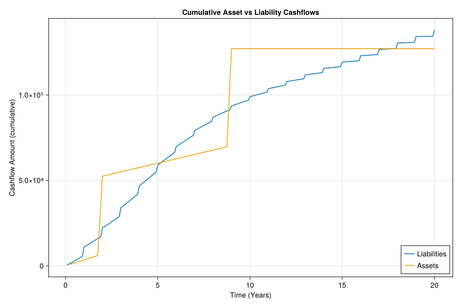

```julia
let
    d = consolidate([p(c) for p in liabilities])
    ks = collect(keys(d)) |> sort!
    vs = -cumsum([d[k] for k in ks])

    f = Figure(size = (900, 600))
    ax = Axis(f[1, 1],
        xlabel = "Time (Years)",
        ylabel = "Cashflow Amount (cumulative)",
        title = "Cumulative Asset vs Liability Cashflows",
    )

    lines!(ax, ks, vs, label = "Liabilities")


    asset_cfs = map(1:length(asset_universe)) do i
        cfs =
            result.weights[i] * asset_universe[i](c)
    end

    d = consolidate(asset_cfs)
    ks2 = collect(keys(d)) |> sort!
    vs2 = cumsum([d[k] for k in ks2])
    lines!(ax, ks2, vs2, label = "Assets")

    axislegend(ax, position = :rb)

    f
end
```

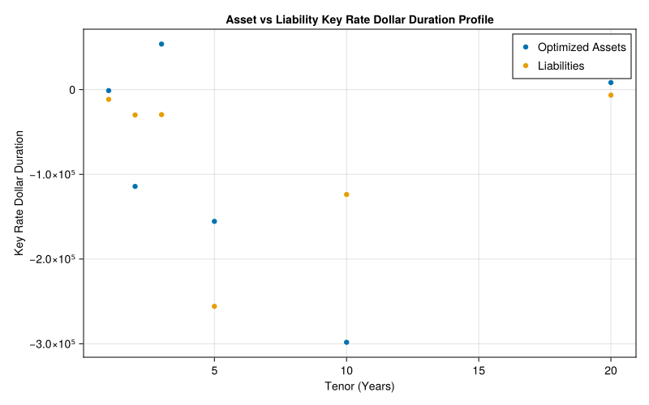

```julia
let
    asset_krds = sum(getindex.(vgh_assets,2) .* result.weights)
    liab_krds = -vgh_liab[2]

    f = Figure(size = (800, 500))
    ax = Axis(f[1, 1],
        xlabel = "Tenor (Years)",
        ylabel = "Key Rate Dollar Duration",
        title = "Asset vs Liability Key Rate Dollar Duration Profile",
    )

    scatter!(ax, times, asset_krds, label = "Optimized Assets")

    scatter!(ax, times, liab_krds, label = "Liabilities")

    axislegend(ax, position = :rt)

    f
end
```

The first plot shows the distribution of asset cashflows over time. The second compares the key rate duration profiles of the optimized asset portfolio and the liability portfolio, demonstrating how well the hedge performs across different points on the yield curve.

**Note**

Production risk teams could rerun this optimization after every major market move. Having gradients and Hessians on tap means the optimizer converges in seconds, so traders can rebalance hedges intra-day without resorting to coarse stress grids.

## 29.7 Computational Benefits

Autodiff provides several advantages over traditional finite difference approaches:

- Exact derivatives rather than approximations
- Efficient computation of derivatives without separate finite difference passes for each parameter
- No tuning of step sizes or dealing with numerical artifacts
- Scales efficiently to high-dimensional parameter spaces

For ALM applications, this means more accurate risk measurement and the ability to optimize portfolios with complex constraints that would be computationally expensive using traditional methods.

Here, we value 100,000 interest-sensitive policies with a monthly timestep for up to 20 years *and* compute 1st and 2nd order partial sensitivities extremely quickly:

```julia
f = z -> annuities(z, liabilities)
@btime value_gradient_and_hessian($f, AutoForwardDiff(), $zero_rates);
```

```
  3.640 s (127244586 allocations: 36.00 GiB)
```

However, there’s still some performance left on the table! The `(d::DeferredAnnuity)(curve)` function defined above is not type stable. In the appendix to this chapter, we’ll cover a way to improve the performance even more.

## 29.8 Conclusion

The Julia ecosystem supports this workflow through packages like `DifferentiationInterface` for autodiff, `JuMP` for optimization, and `FinanceCore` for financial mathematics. This combination enables sophisticated ALM implementations that are both mathematically precise and computationally efficient.

## 29.9 Appendix: Even more performance (Advanced)

Julia is fastest when all functions are type stable (i.e. the return type can be inferred at compile time). Looking back at the function defined above, the issue is that the `av` variable is defined outside of the scope used within the `map` block. This means that the compiler can’t be sure that `av` won’t be modified while being used within the `map`. Therefore, `av` gets boxed and held as an `Any` type. This type uncertainty propagates to the value returned from the `(d::DeferredAnnuity)(curve)` function:

```julia
function (d::DeferredAnnuity)(curve)
    av = 1.0
    map(1//12:1//12:d.tenor) do t
        # apply interest credit
        av *= exp(d.rate / 12)
        # determine market comparable rate and surrender rate
        mkt_rate = -log(curve(d.tenor) / curve(t)) / (d.tenor - t)
        rate_diff = mkt_rate - d.rate
        sr = t == d.tenor ? 1.0 : surrender_rate(rate_diff) / 12
        av_surr = av * sr
        av -= av_surr
        Cashflow(-av_surr, t)
    end
end
```

An alternative would be to write a `for` loop and initialize an array to hold the cashflows. The challenge with that is to concretely define the output type of the resulting array. Particularly when combined with AD, the types within the program are no longer basic floats and integers; we have dual numbers and more complex types running through our functions.

To maintain most of the simplicity, an alternative approach[^1] is to use small, immutable containers from [MicroCollections.jl](https://juliahub.com/ui/Packages/General/MicroCollections) and combine them with [BangBang.jl](https://juliahub.com/ui/Packages/General/BangBang). Then, instead of using `map`, we will write a regular loop. The macro `@unroll` is defined to unroll the first `N` iterations of the loop. This means that the macro transforms the source code to explicitly write out the first two loops. An example of this might be as follows, where two iterations of the loop are unrolled.

```julia
function basic_loop()
    out = []
    for i ∈ 1:10
        push!(out,i)
    end
    out
end

function partially_unrolled_loop()
    out = []
    push!(out,1)
    push!(out,2) # two steps unrolled
    for i ∈ 3:10
        push!(out,i)
    end
    out
end
```

Here’s the macro that does this transformation for us. It takes a loop and unrolls the first `N` iterations, then continues with a regular loop for the remaining iterations:

**Note`@unroll` macro**

```julia
"""
    @unroll N for_loop

Unroll the first `N` iterations of a for loop,
with remaining iterations handled by a regular loop.

This macro takes a for loop and explicitly expands
the first `N` iterations, which can improve performance
and type stability, particularly when building collections
where the first few iterations determine the container's type.

# Arguments
- `N::Int`: # of loop iterations to unroll (must be a compile-time constant)
- `for_loop`: A standard for loop expression

"""
macro unroll(N::Int, loop)
    Base.isexpr(loop, :for) || error("only works on for loops")
    Base.isexpr(loop.args[1], :(=)) || error("Loop pattern not supported")
    val, itr = esc.(loop.args[1].args)
    body = esc(loop.args[2])
    @gensym loopend
    label = :(@label $loopend)
    goto = :(@goto $loopend)
    out = Expr(:block, :(itr = $itr), :(next = iterate(itr)))
    unrolled = map(1:N) do _
        quote
            isnothing(next) && @goto loopend
            $val, state = next
            $body
            next = iterate(itr, state)
        end
    end
    append!(out.args, unrolled)
    remainder = quote
        while !isnothing(next)
            $val, state = next
            $body
            next = iterate(itr, state)
        end
        @label loopend
    end
    push!(out.args, remainder)
    out
end
```

```
Main.Notebook.@unroll
```

Then, we re-write and redefine `(d::DeferredAnnuity)(curve)` to utilize this technique.

```julia
using BangBang, MicroCollections

function (d::DeferredAnnuity)(curve)
    times = 1//12:1//12:d.tenor
    out = UndefVector{Union{}}(length(times)) # 1
    av = 1.0
    @unroll 2 for (i, t) ∈ enumerate(times) # 2
        mkt_rate = -log(curve(d.tenor) / curve(t)) / (d.tenor - t)
        av *= exp(d.rate / 12)
        rate_diff = mkt_rate - d.rate
        sr = t == d.tenor ? 1.0 : surrender_rate(rate_diff) / 12
        av_surr = av * sr
        av -= av_surr
        cf = Cashflow(-av_surr, t)
        out = setindex!!(out, cf, i) # 3
    end
    out
end;
```

1. We tell the `out` vector how many elements to expect.
2. We unroll two iterations of the loop so that the compiler can use the calculated result to determine the type of the output container.
3. We use `setindex!!` from BangBang to efficiently update the output vector and its type.

Using this technique, we can see that we achieve a significant speedup (less than half the runtime) from the earlier version due to improving the type stability of the code:

```julia
f = z -> annuities(z, liabilities)
@btime value_gradient_and_hessian($f, AutoForwardDiff(), $zero_rates);
```

```
  1.686 s (600186 allocations: 5.41 GiB)
```

[^1]: With thanks to the helpful people on the Julia Zulip and in particular Mason Protter for this approach.